# Simulating Individual Tumor Dynamics and Their Link to Survival: A Two-Stage Approach

Portfolio project — Pharmacometrics-inspired modeling in oncology

Juliette Bouli-Mengue

## 1. Motivation

In oncology drug development, individual tumor size trajectories (typically summarized as Sum of Longest Diameters, SLD, per RECIST criteria) are often linked to survival outcomes (Progression-Free Survival, PFS; Overall Survival, OS) to support dose selection and efficacy predictions. This notebook demonstrates, on **fully simulated data**, the classic “two-stage” approach used in pharmacometrics: individual tumor dynamics parameters are first estimated from longitudinal measurements, then used as covariates in a survival model.

No real patient data is used here. The goal is to demonstrate methodological understanding before applying the same logic to real datasets.

### The Tumor Growth Inhibition (TGI) model

We use the biexponential TGI model (Wang et al., *Clin Pharmacol Ther*, 2009):

$$SLD(t) = SLD_0 \times (e^{-g \cdot t} +
e^{d \cdot t} - 1)$$

- **g**: tumor regression rate (treatment effect)
- **d**: tumor regrowth rate (resistance)
- **SLD0**: baseline tumor size

```r
library(minpack.lm)
library(survival)
library(survminer)
library(dplyr)
library(ggplot2)

set.seed(42)
```

## 2. Simulating “true” individual patient parameters

We simulate 200 patients. Each has their own growth (`g`), regrowth (`d`), and baseline tumor size (`SLD0`), drawn from log-normal distributions to reflect realistic between-patient variability (parameters must be strictly positive, and biological rate parameters are typically right-skewed).

```r
n_patients <- 200

g_pop      <- 0.020
omega_g    <- 0.5
d_pop      <- 0.010
omega_d    <- 0.6
SLD0_pop   <- 60
omega_SLD0 <- 0.3

patients <- tibble(
  patient_id = 1:n_patients,
  g    = rlnorm(n_patients, log(g_pop), omega_g),
  d    = rlnorm(n_patients, log(d_pop), omega_d),
  SLD0 = rlnorm(n_patients, log(SLD0_pop), omega_SLD0)
)

head(patients)
```

```
## # A tibble: 6 × 4
##   patient_id      g       d  SLD0
##        <int>  <dbl>   <dbl> <dbl>
## 1          1 0.0397 0.00301  89.6
## 2          2 0.0151 0.0122   46.2
## 3          3 0.0240 0.0202   61.0
## 4          4 0.0274 0.0344   60.9
## 5          5 0.0245 0.00438  50.4
## 6          6 0.0190 0.00501  44.5
```

## 3. Simulating survival outcomes

Survival is simulated using a proportional hazards structure: a higher `g` (better response) protects the patient (reduces hazard), while a higher `d` (faster regrowth) increases the hazard. This mirrors the clinical rationale that tumor dynamics parameters carry prognostic information.

```r
beta_g <- -15   # protective effect of g
beta_d <- 20    # detrimental effect of d
h0     <- 0.015 # baseline hazard

patients <- patients %>%
  mutate(
    g_c = g - mean(g),
    d_c = d - mean(d),
    linear_pred = beta_g * g_c + beta_d * d_c,
    hazard = h0 * exp(linear_pred),
    true_event_time = rexp(n(), rate = hazard)
  )

admin_censoring <- 104

patients <- patients %>%
  mutate(
    os_time  = pmin(true_event_time, admin_censoring),
    os_event = as.integer(true_event_time <= admin_censoring)
  )

summary(patients$os_time)
```

```
##     Min.  1st Qu.   Median     Mean  3rd Qu.     Max.
##   0.1309  22.7826  52.3495  54.6773  93.3075 104.0000
```

```r
table(patients$os_event)
```

```
##
##   0   1
##  46 154
```

A quick sanity check: patients with higher `g` should tend to survive longer.

```r
cor.test(patients$g, patients$os_time, method = "spearman")
```

```
##
##  Spearman's rank correlation rho
##
## data:  patients$g and patients$os_time
## S = 1049359, p-value = 0.002465
## alternative hypothesis: true rho is not equal to 0
## sample estimates:
##      rho
## 0.212961
```

## 4. First attempt: sparse sampling design

We first simulate a realistic but relatively sparse observation schedule: a scan every 6 weeks, with 15% multiplicative measurement noise (a plausible level of imaging imprecision).

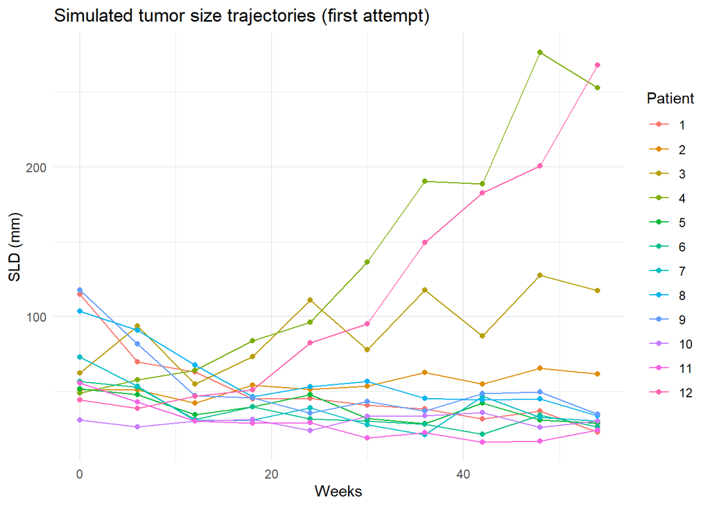

```r
assessment_times <- seq(0, 54, by = 6)
sigma_obs <- 0.15

longitudinal_data <- patients %>%
  rowwise() %>%
  do({
    pt <- .
    tibble(
      patient_id = pt$patient_id,
      time = assessment_times,
      SLD_true = pt$SLD0 * (exp(-pt$g * assessment_times) + exp(pt$d * assessment_times) - 1)
    )
  }) %>%
  ungroup() %>%
  mutate(SLD_obs = SLD_true * exp(rnorm(n(), 0, sigma_obs))) %>%
  filter(SLD_obs > 0)

ggplot(longitudinal_data %>% filter(patient_id <= 12),
       aes(x = time, y = SLD_obs, group = patient_id, color = factor(patient_id))) +
  geom_line() + geom_point() +
  labs(title = "Simulated tumor size trajectories (first attempt)",
       x = "Weeks", y = "SLD (mm)", color = "Patient") +
  theme_minimal()
```

### Stage 1: re-estimating g and d per patient from noisy scans

We now act as if the true `g` and `d` were unknown, and re-estimate them for each patient from their noisy longitudinal measurements only, using nonlinear least squares.

```r
fit_one_patient <- function(df) {
  tryCatch({
    fit <- nlsLM(
      SLD_obs ~ SLD0_est * (exp(-g_est * time) + exp(d_est * time) - 1),
      data = df,
      start = list(SLD0_est = df$SLD_obs[df$time == 0][1], g_est = 0.02, d_est = 0.01),
      lower = c(SLD0_est = 1, g_est = 0.0001, d_est = 0.0001),
      upper = c(SLD0_est = 500, g_est = 1, d_est = 1),
      control = nls.lm.control(maxiter = 200)
    )
    coefs <- coef(fit)
    tibble(g_hat = coefs["g_est"], d_hat = coefs["d_est"], convergence = TRUE)
  }, error = function(e) {
    tibble(g_hat = NA_real_, d_hat = NA_real_, convergence = FALSE)
  })
}

individual_fits <- longitudinal_data %>%
  group_by(patient_id) %>%
  filter(n() >= 4) %>%
  group_modify(~ fit_one_patient(.x)) %>%
  ungroup()

cat("Convergence rate:", mean(individual_fits$convergence, na.rm = TRUE) * 100, "%\n")
```

```
## Convergence rate: 100 %
```

### Stage 2: Cox model on the re-estimated parameters

```r
analysis_data <- patients %>%
  inner_join(individual_fits, by = "patient_id") %>%
  filter(convergence, !is.na(g_hat), !is.na(d_hat))

cox_model_v1 <- coxph(Surv(os_time, os_event) ~ g_hat + d_hat, data = analysis_data)
summary(cox_model_v1)
```

```
## Call:
## coxph(formula = Surv(os_time, os_event) ~ g_hat + d_hat, data = analysis_data)
##
##   n= 200, number of events= 154
##
##             coef  exp(coef)   se(coef)     z Pr(>|z|)
## g_hat -1.056e+01  2.583e-05  4.715e+00 -2.24   0.0251 *
## d_hat  2.042e+01  7.416e+08  8.581e+00  2.38   0.0173 *
## ---
## Signif. codes:  0 '***' 0.001 '**' 0.01 '*' 0.05 '.' 0.1 ' ' 1
##
##       exp(coef) exp(-coef) lower .95 upper .95
## g_hat 2.583e-05  3.871e+04 2.502e-09 2.666e-01
## d_hat 7.416e+08  1.349e-09 3.678e+01 1.495e+16
##
## Concordance= 0.6  (se = 0.023 )
## Likelihood ratio test= 10.04  on 2 df,   p=0.007
## Wald test            = 10.89  on 2 df,   p=0.004
## Score (logrank) test = 10.93  on 2 df,   p=0.004
```

```r
cor(analysis_data$g, analysis_data$g_hat)
```

```
## [1] 0.5770104
```

```r
cor(analysis_data$d, analysis_data$d_hat)
```

```
## [1] 0.9130984
```

### First result: the signal is diluted

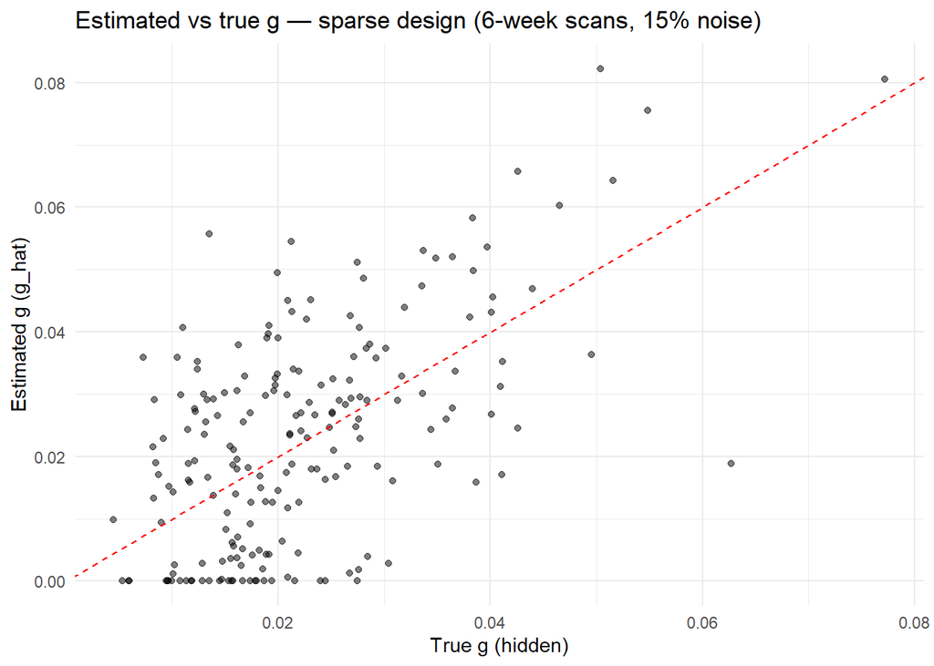

```r
ggplot(analysis_data, aes(x = g, y = g_hat)) +
  geom_point(alpha = 0.5) +
  geom_abline(slope = 1, intercept = 0, color = "red", linetype = "dashed") +
  labs(title = "Estimated vs true g — sparse design (6-week scans, 15% noise)",
       x = "True g (hidden)", y = "Estimated g (g_hat)") +
  theme_minimal()
```

This is a textbook case of **attenuation by measurement error**: when an explanatory variable is estimated with substantial noise, its estimated effect on the outcome is biased towards zero, even if the true underlying effect is strong. The asymmetry between `g` and `d` recovery is itself informative: over this observation window, the regrowth signal (`d`) tends to dominate the tumor trajectory towards the end of follow-up, giving the optimizer a clearer signal for `d` than for the earlier, more transient regression phase captured by `g` — an **identifiability** issue rather than a modeling error.

## 5. Adjusting the observation design

Rather than treating this as a dead end, we adjust two aspects of the *simulated clinical trial design* — which is a legitimate lever in real protocol planning:

- **Scan frequency**: every 3 weeks instead of every 6, over a longer follow-up window (72 weeks instead of 54), giving 25 measurements per patient instead of 10.
- **Measurement noise**: reduced from 15% to 8%, still realistic but less extreme.

```r
assessment_times <- seq(0, 72, by = 3)
sigma_obs <- 0.08

longitudinal_data <- patients %>%
  rowwise() %>%
  do({
    pt <- .
    tibble(
      patient_id = pt$patient_id,
      time = assessment_times,
      SLD_true = pt$SLD0 * (exp(-pt$g * assessment_times) + exp(pt$d * assessment_times) - 1)
    )
  }) %>%
  ungroup() %>%
  mutate(SLD_obs = SLD_true * exp(rnorm(n(), 0, sigma_obs))) %>%
  filter(SLD_obs > 0)
```

We re-run the exact same two-stage pipeline on this improved design.

```r
individual_fits <- longitudinal_data %>%
  group_by(patient_id) %>%
  filter(n() >= 4) %>%
  group_modify(~ fit_one_patient(.x)) %>%
  ungroup()

cat("Convergence rate:", mean(individual_fits$convergence, na.rm = TRUE) * 100, "%\n")
```

```
## Convergence rate: 100 %
```

```r
analysis_data <- patients %>%
  inner_join(individual_fits, by = "patient_id") %>%
  filter(convergence, !is.na(g_hat), !is.na(d_hat))

cox_model_v2 <- coxph(Surv(os_time, os_event) ~ g_hat + d_hat, data = analysis_data)
summary(cox_model_v2)
```

```
## Call:
## coxph(formula = Surv(os_time, os_event) ~ g_hat + d_hat, data = analysis_data)
##
##   n= 200, number of events= 154
##
##             coef  exp(coef)   se(coef)      z Pr(>|z|)
## g_hat -1.823e+01  1.215e-08  6.741e+00 -2.704  0.00686 **
## d_hat  2.686e+01  4.609e+11  9.222e+00  2.912  0.00359 **
## ---
## Signif. codes:  0 '***' 0.001 '**' 0.01 '*' 0.05 '.' 0.1 ' ' 1
##
##       exp(coef) exp(-coef) lower .95 upper .95
## g_hat 1.215e-08   8.23e+07 2.221e-14 6.648e-03
## d_hat 4.609e+11   2.17e-12 6.515e+03 3.260e+19
##
## Concordance= 0.608  (se = 0.023 )
## Likelihood ratio test= 16.26  on 2 df,   p=3e-04
## Wald test            = 18.15  on 2 df,   p=1e-04
## Score (logrank) test = 17.94  on 2 df,   p=1e-04
```

```r
cor(analysis_data$g, analysis_data$g_hat)
```

```
## [1] 0.8094439
```

```r
cor(analysis_data$d, analysis_data$d_hat)
```

```
## [1] 0.9940573
```

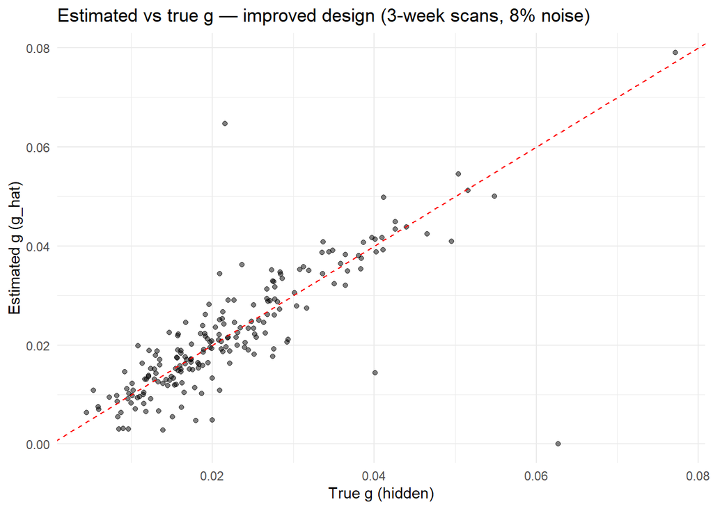

```r
ggplot(analysis_data, aes(x = g, y = g_hat)) +
  geom_point(alpha = 0.5) +
  geom_abline(slope = 1, intercept = 0, color = "red", linetype = "dashed") +
  labs(title = "Estimated vs true g — improved design (3-week scans, 8% noise)",
       x = "True g (hidden)", y = "Estimated g (g_hat)") +
  theme_minimal()
```

## 6. Summary of the two-stage results

[output not shown]

The two-stage approach, however, still has a structural limitation: it treats parameter estimation and survival modeling as two independent steps, ignoring the uncertainty of `g_hat`/`d_hat` when they are reused as fixed covariates. This motivates the joint modeling approach developed in the companion notebook (`02_joint_model.Rmd`), where the longitudinal trajectory and survival are estimated simultaneously.

```r
saveRDS(patients, "patients_final.rds")
saveRDS(longitudinal_data, "longitudinal_data_final.rds")
```